# What Auckland Wears: A Street Style Market Intelligence Report

**Making Colour Palettable** — *A street style market intelligence report*

This report draws on observational data I collected across the University of Auckland campus and my commute home through central Auckland, on buses and trains, between March and May 2026. A total of 115 outfits were logged across morning, afternoon, and evening periods, capturing aesthetic category, colour palette, garment count, and brand visibility. I wasn’t sure what I would find; however, seeing the trends through data was genuinely surprising.

What we wear is largely subconscious. Without even realising it, our outfits are shaped by the spaces we moved through our culture, and the general mood of the world around us. Seeing those choices rendered as data makes the invisible visible. Most of us get dressed without thinking too deeply about it, but collectively our outfits tell a bigger story.

## The Auckland Uniform

Streetwear dominated across campus and commute, as well as across demographics and times of day. This wasn’t entirely surprising, as streetwear is the defining aesthetic of current era, born from coming together of global cultures, hip-hop heritage, and the democratisation of fashion through social media. However, what is surprising is the sheer prevalence of it here in Auckland.

Something else worth noting is that the categories themselves are blurring. Cultural dress can also be read as streetwear. Formal was harder to define as it edges into casual. The academic language of fashion feels increasingly inadequate for a world where boundaries are dissolving. However, one thing is clear that there is one prevailing mode, and it is consistent across a diverse range of people.

To express the prevailing streetwear trends, most people wore two to three garments across genders, a welcome sign of the times.

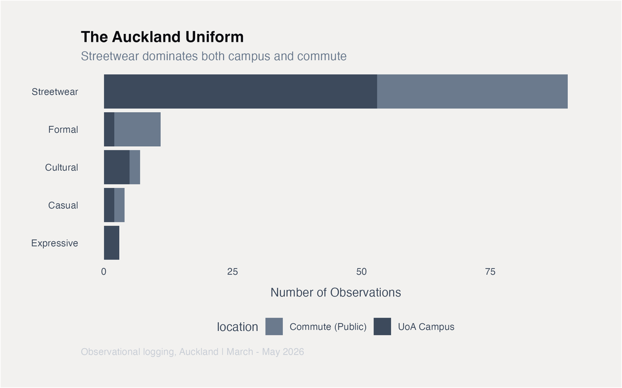

Bar chart showing dominant aesthetic by location, Auckland 2026

## Dressed for Mild

Auckland’s climate is transeasonal by nature. Minus the rain, the city demands relatively little from its dressers due to a lack of extreme temperature swings, and the data confirms this. Garment count stays flat across the entire collection period, from late summer through autumn. Two to three pieces, consistently, regardless of the hour or the day.

What changes is not quantity but composition, tees give way to hoodies, jackets layer over basics, yet the total garment count remains flat. Layering, in this context, is minimal rather than expressive. This absence also suggests an opportunity for *considered layering*. Garments designed not just to add warmth, but to enable transition between roles, environments, and times of day. As these transitions increasingly unfold in digital space, where physical cues of time are less defined, the potential for adaptive, transformative design feels especially relevant.

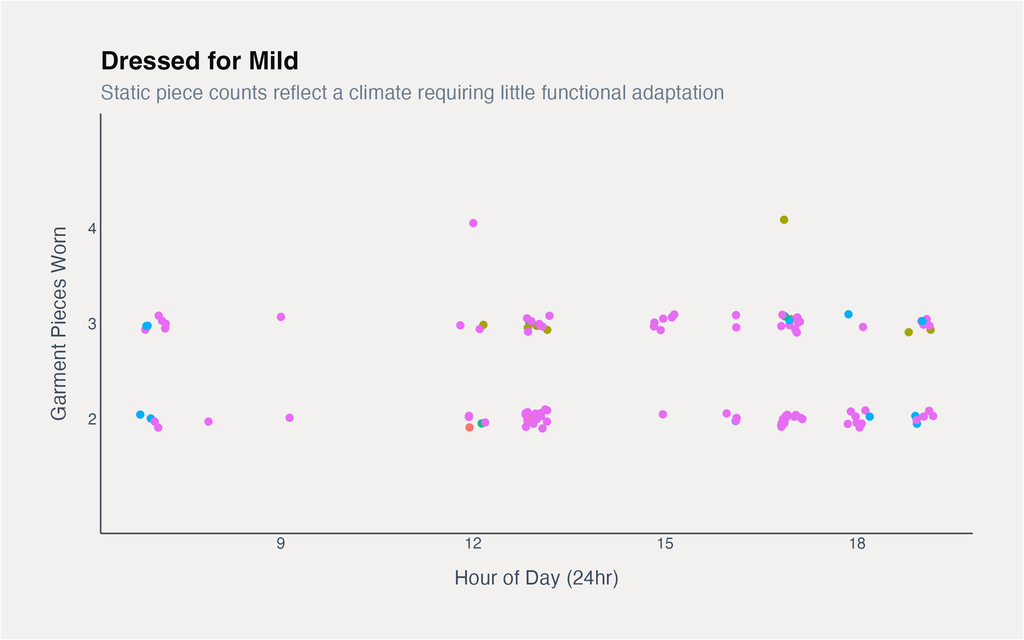

Jitter plot showing garment count by hour of day, Auckland 2026

## The Opportunity Gap

Of all the findings, it is the colour data that speaks most clearly to the current moment and it’s something that surprised me when seen through data visualisation. Neutrals and earth tones dominate completely, especially, full spectrum of greys, deep denim blues, muted browns, and greens. Bold or bright colour is noticeably absent and mixed pattern is also extremely rare.

This signals a collective tendency to blend in. For a nation defined by its natural beauty, the palette is recognisable, but still notably subdued. A stark contrast to the pop colours of the 1960s or the jewel tones of the 1980s, where colour operated as expression. Here, it feels more like calibration. These are colours of quiet navigation. Individuals moving through a world that is rapidly shifting, technologically and geopolitically. As more of life is lived in digital space, where expression is increasingly channelled online rather than through physical dress, what we wear becomes more neutral, more adaptable, less declarative.

This is where the opportunity lies.

The market is not oversaturated with colour, it is defined by its absence. For a brand with the conviction to introduce considered, joyful colour in a way that feels wearable, adaptable, and in step with the rhythms of modern life, the white space is wide open.

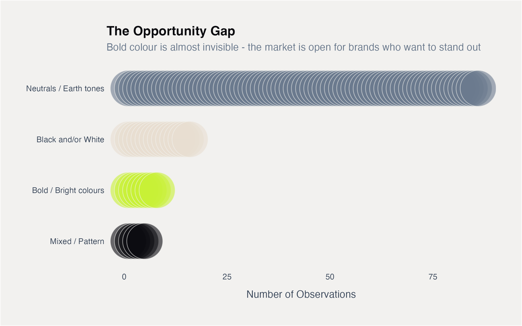

Dot plot showing colour palette distribution, Auckland 2026